# Data Science Capstone -Week 2

rmydeen

8/20/2020

## Data Science Specialization Capstone, Week 2

Coursera Data Science Specialization provides basic skills to play a data scientist role.Goal of this project is to simulate the experience of being a data scientist effectively.

The project consists of developing a predictive model of text (Predictive Text Analytics) using a swifkey company dataset provided.

This exercise will have steps to download the dataset, understanding it, cleaning it and do some analysis. This document describes the Exploratory Data Analysis done,and major characteristics of the data that have been present and a summary of plan of how to build a prediction algorithm next and also how to create a Shiny app in a way that is understandable to anybody.

## 1. Download Data

Swift Key data set can be downloded using following link - For this analysis data downloaded from same link placed here.

Download step can be automated as well- Manual step here

https://d396qusza40orc.cloudfront.net/dsscapstone/dataset/Coursera-SwiftKey.zip

This data set having multiple language files and considered only english version. After extracting files - Following files can be found like 1.en_US.blogs.txt - Blogs text 2.en_US.news.txt - News feed text 3.en_US.twitter.txt - Twitte text

```r
library(R.utils)
library(stringr)
setwd("C://CodeProjects/CapstoneProject/Coursera-SwiftKey/final/en_US/")
filepat <- "C://CodeProjects/CapstoneProject/Coursera-SwiftKey/final/en_US"
# list_file <- list.files(pattern = "*.txt")
# for (k in 1:length(list_file)){
#   pathname <- list_file[k]
#
#  n <- countLines(pathname)
#  filecont <- readLines(file(pathname, "rb"), encoding="UTF-8", skipNul=TRUE)
#  #file_length <- sapply(filecont,nchar)
#  print(paste0("File  :",pathname," Lines : ",n),quote = FALSE, row.names = FALSE)
#
#
# }
getTexts <- function(filepath,nline){

    if (nline == 0 ){
     con <- file(filepath,"rb")
     #on.exit(close(con))
     texts <-readLines(con,encoding="UTF-8", skipNul=TRUE)
     close(con)
     }
    else{
       con <- file(filepath,"r")
       #on.exit(close(con))
       texts <-readLines(con,nline,encoding="UTF-8", skipNul=TRUE)
       close(con)
    }

    texts
}
getMaxLine <- function(fText,nlines){
  maxline <- 0
  for (i in 1:nlines) {
    linelength <- nchar(fText[i])
    if (linelength > maxline) { maxline <- linelength }
  }
  maxline
}
fileNews <- paste0(filepat,"/en_US.news.txt")
fileBlogs <- paste0(filepat,"/en_US.blogs.txt")
fileTwitter <- paste0(filepat,"/en_US.twitter.txt")
nCount <- countLines(fileNews)
bCount <- countLines(fileBlogs)
tCount <- countLines(fileTwitter)
news <- getTexts(fileNews,0)
blogs <- getTexts(fileBlogs,0)
twitter <-getTexts(fileTwitter,0)
nlines <- length(news)
blines <- length(blogs)
tlines <- length(twitter)
nwords <- sum(stri_count_words(news))
bwords <- sum(stri_count_words(blogs))
twords <- sum(stri_count_words(twitter))
nmax <- getMaxLine(news,nlines)
bmax <- getMaxLine(blogs,blines)
tmax <- getMaxLine(twitter,tlines)
matrix(c(nCount,nmax,nwords,
         bCount,bmax,bwords,
         tCount,tmax,twords),
      nrow = 3, ncol = 3, byrow = TRUE,
      dimnames = list(c("News Info:", "Blog Info:", "Twitter Info:"),
                 c("No of Lines", "Longest Line", "No. of words")))
```

```
##               No of Lines Longest Line No. of words
## News Info:        1010242        11384     34762395
## Blog Info:         899288        40833     37546239
## Twitter Info:     2360148          140     30093413
```

## 2.Data sample

```r
newsSam <-   getTexts(fileNews, 750)
blogsSam <-  getTexts(fileBlogs, 500)
twitterSam <-   getTexts(fileTwitter, 200)

corpus_EN <- VCorpus(VectorSource(c(newsSam, blogsSam, twitterSam)), readerControl=list(readPlain, language="en", load=TRUE))
```

## 3. Data Cleaning

Cleaning data here for samples

```r
corpus_clean <- tm_map(corpus_EN, content_transformer(tolower))
rm(corpus_EN)
corpus_clean <- tm_map(corpus_clean, content_transformer(removePunctuation))
corpus_clean <- tm_map(corpus_clean, content_transformer(stripWhitespace))
corpus_clean <- tm_map(corpus_clean, content_transformer(stemDocument), language = "english")
corpus_clean <- tm_map(corpus_clean, content_transformer(removeNumbers))
save(corpus_clean,file="sample_corpus")
```

## 4. Analysis of n-gram

```r
tdm1 <-  TermDocumentMatrix(corpus_clean)
save(tdm1,file="tdm1")
```

```r
bigram <- function(x) NGramTokenizer(x, Weka_control(min = 2, max = 2))
tdm2 <-  TermDocumentMatrix(corpus_clean,control = list(tokenize = bigram))
save(tdm2,file="tdm2")
```

```r
trigram <- function(x) NGramTokenizer(x, Weka_control(min = 3, max = 3))
tdm3 <- TermDocumentMatrix(corpus_clean,control = list(tokenize = trigram))
save(tdm3,file="tdm3")
```

```r
memory.limit(size=56000)
```

```
## [1] 56000
```

```r
load("tdm1")
gram_1 = as.data.frame(as.matrix(tdm1 ) )
gram_1v <- sort(rowSums(gram_1),decreasing=TRUE)
gram_1d <- data.frame(word = names(gram_1v),freq=gram_1v)
gram_1d[1:10,]
```

```
##      word freq
## the   the 4348
## and   and 2210
## that that 1019
## for   for  928
## with with  665
## you   you  609
## was   was  578
## have have  477
## but   but  448
## this this  434
```

```r
load("tdm2")
gram_2= as.data.frame(as.matrix( tdm2) )
gram_2v <- sort(rowSums(gram_2),decreasing=TRUE)
gram_2d  <- data.frame(word = names(gram_2v),freq=gram_2v)
gram_2d[1:10,]
```

```
##              word freq
## of the     of the  392
## in the     in the  381
## to the     to the  196
## for the   for the  168
## to be       to be  167
## on the     on the  166
## and the   and the  120
## in a         in a  120
## at the     at the  119
## with the with the  100
```

```r
load("tdm3")
gram_3 = as.data.frame(as.matrix(tdm3) )
gram_3v <- sort(rowSums(gram_3),decreasing=TRUE)
gram_3d <- data.frame(word = names(gram_3v),freq=gram_3v)
gram_3d[1:10,]
```

```
##                  word freq
## a lot of     a lot of   43
## one of the one of the   31
## i want to   i want to   22
## a coupl of a coupl of   15
## as much as as much as   14
## i had a       i had a   14
## the end of the end of   14
## be abl to   be abl to   13
## it is a       it is a   13
## it was a     it was a   13
```

## 5. Plot of top 15

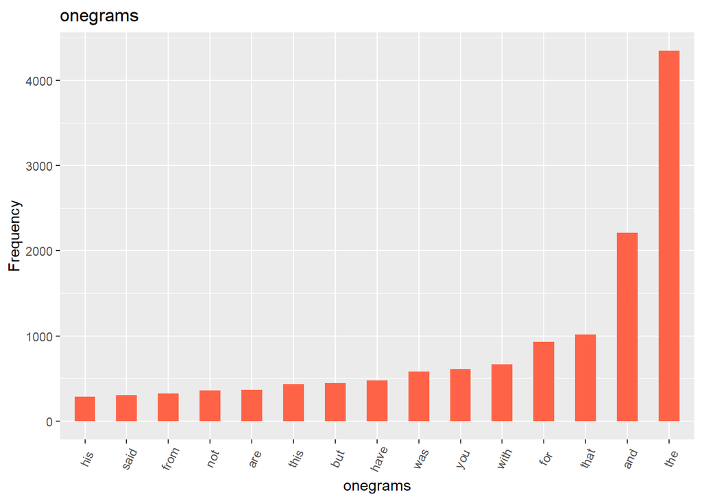

```r
ggplot(gram_1d[1:15,], aes(x=reorder(word, freq),y=freq)) +
        geom_bar(stat="identity", width=0.5, fill="tomato1") +
        labs(title="onegrams")+
        xlab("onegrams") + ylab("Frequency") +
        theme(axis.text.x=element_text(angle=65, vjust=0.6))
```

```r
wordcloud2(gram_2d[1:15,],size=1.6,shape = 'star')
```

[interactive chart not shown]